# IAT regressions with Age

Molly Lewis

2018-07-30

These analyses predict iat behavioral, language iat measure, objective equality measures (ggi, wps, percentage women in stem). GGI and WPS are standard measures of gender equality with larger numbers indicating higher equality. Percentage women in stem comes from Stoet and Geary paper (there are also misc other objective variables from this paper)

The analyses are done at three different levels - participant, country, and language.

The resid values are the iat scores (impicit and explicit) residualizing out age, sex (resid1), and age, sex relgiosity, and explicit/implicit score (resid2).

*Participant level findings*

*Country level findings*

- GGI predicts behavioral iat, controling for stuff in regression, in the predicted direction: higher ggi, lower bias. But effect of ggi goes away whne you look at residuals.
- However, for WPS, the effect is in the same direction as at the participant level: higher wps, higher behavioral bias.
- GGI predicts women in stem measure in same direction as participant level: higher ggi, lower percentage of women in stem (this is the Stoet and Geary 2018 effect)
- Importantly, es_behavioral_iat also predict percentage of women in stem, controling for ggi and explicit beliefs: higher iat bias, lower percentage of women in stem.

So the relationship between objective measures of equality and behavioral iat is the same between participant and country level (more equality, more bias), except for one regression (iat~ggi + age etc.).

*Language level findings*

- career language iat does not predict behavioral iat, when you control for mean age of participants, but the effect is in the predicted direction
- flower language iat does not predict behavioral iat at all
- career language iat does not predict percentage women measure, but does predict satisfaction (from Stoet and Geary), even after controlling for ggi

```r
PARTICIPANT_DF_PATH <- "by_participant_df.csv"
LANGUAGE_DF_PATH <- "by_language_df.csv"
COUNTRY_DF_PATH <- "by_country_df.csv"
```

```r
participant_df_raw <- read_csv(PARTICIPANT_DF_PATH)
participant_df <- participant_df_raw %>%
  mutate(es_iat_sex_age_order_explicit_resid = as.numeric(es_iat_sex_age_order_explicit_resid),
         order = as.factor(order),
          es_iat_sex_age_order_implicit_resid = as.numeric( es_iat_sex_age_order_implicit_resid)) %>%
  mutate_at(vars(education, religionid), as.numeric) %>%
  mutate_at(vars(overall_iat_D_score, log_age, religionid, explicit_dif, es_iat_sex_age_order_explicit_resid, es_iat_sex_age_order_implicit_resid, median_age), scale_this)

language_df <- read_csv(LANGUAGE_DF_PATH) %>%
    mutate_if(is.numeric, scale_this)
```

## Participant Level

```r
country_df <- read_csv(COUNTRY_DF_PATH)
participant_df_full <- participant_df %>%
  left_join(country_df %>% select(country_code:satisfaction, wiki_language_code),
            by = c("countryres" = "country_code")) %>%
  left_join(language_df %>% select(career_hand, wiki_language_code))
```

### Raw correlations

```r
participant_df_corr <- participant_df_full %>%
  select_if(is.numeric)

corr_mat <- cor(participant_df_corr,
                use = "pairwise.complete.obs")

p.mat <- corrplot::cor.mtest(participant_df_corr,
                  conf.level = (1-ALPHA),
                  use = "pairwise.complete.obs")$p

corrplot::corrplot(corr_mat, method = "color",  col = cols,
         order = "original", number.cex = .7,
         addCoef.col = "black",
         p.mat = p.mat, sig.level = ALPHA, insig = "blank",
         tl.col = "black", tl.srt = 90,
         diag = FALSE)
```

[output not shown]

### Regressions

#### ggi predicts iat score

```r
lm(overall_iat_D_score ~  ggi  + log_age + median_age +  as.factor(sex)  + order,
data = participant_df_full) %>%
  summary()
```

```
##
## Call:
## lm(formula = overall_iat_D_score ~ ggi + log_age + median_age +
##     as.factor(sex) + order, data = participant_df_full)
##
## Residuals:
##     Min      1Q  Median      3Q     Max
## -6.4045 -0.6376  0.0532  0.6882  4.0111
##
## Coefficients:
##                  Estimate Std. Error  t value Pr(>|t|)
## (Intercept)      0.086499   0.061309    1.411   0.1583
## ggi             -0.182162   0.084678   -2.151   0.0315 *
## log_age          0.067471   0.001241   54.366   <2e-16 ***
## median_age       0.015226   0.001406   10.826   <2e-16 ***
## as.factor(sex)1 -0.280449   0.002726 -102.881   <2e-16 ***
## order2           0.250910   0.002465  101.801   <2e-16 ***
## ---
## Signif. codes:  0 '***' 0.001 '**' 0.01 '*' 0.05 '.' 0.1 ' ' 1
##
## Residual standard error: 0.9811 on 633961 degrees of freedom
##   (29742 observations deleted due to missingness)
## Multiple R-squared:  0.0355, Adjusted R-squared:  0.03549
## F-statistic:  4666 on 5 and 633961 DF,  p-value: < 2.2e-16
```

```r
lm(overall_iat_D_score ~  wps  + log_age + median_age +  as.factor(sex)  + order,
data = participant_df_full) %>%
  summary()
```

```
##
## Call:
## lm(formula = overall_iat_D_score ~ wps + log_age + median_age +
##     as.factor(sex) + order, data = participant_df_full)
##
## Residuals:
##     Min      1Q  Median      3Q     Max
## -6.4048 -0.6375  0.0533  0.6882  4.0107
##
## Coefficients:
##                  Estimate Std. Error  t value Pr(>|t|)
## (Intercept)     -0.100344   0.049892   -2.011   0.0443 *
## wps              0.067886   0.061514    1.104   0.2698
## log_age          0.067340   0.001239   54.333  < 2e-16 ***
## median_age       0.011505   0.002021    5.694 1.24e-08 ***
## as.factor(sex)1 -0.280449   0.002726 -102.896  < 2e-16 ***
## order2           0.251039   0.002463  101.920  < 2e-16 ***
## ---
## Signif. codes:  0 '***' 0.001 '**' 0.01 '*' 0.05 '.' 0.1 ' ' 1
##
## Residual standard error: 0.9811 on 634824 degrees of freedom
##   (28879 observations deleted due to missingness)
## Multiple R-squared:  0.0355, Adjusted R-squared:  0.03549
## F-statistic:  4673 on 5 and 634824 DF,  p-value: < 2.2e-16
```

```r
lm(overall_iat_D_score ~  ggi  + log_age + median_age +  as.factor(sex)  + order + explicit_dif + religionid,
data = participant_df_full) %>%
  summary()
```

```
##
## Call:
## lm(formula = overall_iat_D_score ~ ggi + log_age + median_age +
##     as.factor(sex) + order + explicit_dif + religionid, data = participant_df_full)
##
## Residuals:
##     Min      1Q  Median      3Q     Max
## -6.4653 -0.6247  0.0490  0.6724  3.6825
##
## Coefficients:
##                  Estimate Std. Error  t value Pr(>|t|)
## (Intercept)     -0.009716   0.086616   -0.112    0.911
## ggi             -0.007674   0.119732   -0.064    0.949
## log_age          0.064741   0.001463   44.261   <2e-16 ***
## median_age       0.019950   0.001737   11.485   <2e-16 ***
## as.factor(sex)1 -0.334549   0.003342 -100.103   <2e-16 ***
## order2           0.255004   0.002957   86.243   <2e-16 ***
## explicit_dif     0.138963   0.001406   98.817   <2e-16 ***
## religionid       0.018526   0.001487   12.457   <2e-16 ***
## ---
## Signif. codes:  0 '***' 0.001 '**' 0.01 '*' 0.05 '.' 0.1 ' ' 1
##
## Residual standard error: 0.9616 on 423233 degrees of freedom
##   (240468 observations deleted due to missingness)
## Multiple R-squared:  0.06382,    Adjusted R-squared:  0.06381
## F-statistic:  4122 on 7 and 423233 DF,  p-value: < 2.2e-16
```

```r
lm(overall_iat_D_score ~  wps  + log_age + median_age +  as.factor(sex)  + order + explicit_dif + religionid,
data = participant_df_full) %>%
  summary()
```

```
##
## Call:
## lm(formula = overall_iat_D_score ~ wps + log_age + median_age +
##     as.factor(sex) + order + explicit_dif + religionid, data = participant_df_full)
##
## Residuals:
##     Min      1Q  Median      3Q     Max
## -6.4658 -0.6246  0.0491  0.6724  3.6820
##
## Coefficients:
##                  Estimate Std. Error  t value Pr(>|t|)
## (Intercept)     -0.105010   0.062641   -1.676   0.0937 .
## wps              0.110651   0.077195    1.433   0.1517
## log_age          0.064774   0.001461   44.341  < 2e-16 ***
## median_age       0.015631   0.002644    5.912 3.38e-09 ***
## as.factor(sex)1 -0.334479   0.003342 -100.087  < 2e-16 ***
## order2           0.255103   0.002955   86.336  < 2e-16 ***
## explicit_dif     0.138994   0.001405   98.918  < 2e-16 ***
## religionid       0.018364   0.001487   12.350  < 2e-16 ***
## ---
## Signif. codes:  0 '***' 0.001 '**' 0.01 '*' 0.05 '.' 0.1 ' ' 1
##
## Residual standard error: 0.9617 on 423836 degrees of freedom
##   (239865 observations deleted due to missingness)
## Multiple R-squared:  0.06386,    Adjusted R-squared:  0.06385
## F-statistic:  4130 on 7 and 423836 DF,  p-value: < 2.2e-16
```

#### language also iat predicts iat score

```r
lm(overall_iat_D_score ~  career_hand +  ggi + log_age + median_age +  religionid  +  explicit_dif + as.factor(sex) + order,
data = participant_df_full) %>%
  summary()
```

```
##
## Call:
## lm(formula = overall_iat_D_score ~ career_hand + ggi + log_age +
##     median_age + religionid + explicit_dif + as.factor(sex) +
##     order, data = participant_df_full)
##
## Residuals:
##     Min      1Q  Median      3Q     Max
## -6.4668 -0.6245  0.0491  0.6723  3.6821
##
## Coefficients:
##                  Estimate Std. Error t value Pr(>|t|)
## (Intercept)      0.040108   0.105085   0.382   0.7027
## career_hand      0.015018   0.007641   1.966   0.0494 *
## ggi             -0.089432   0.147306  -0.607   0.5438
## log_age          0.064576   0.001473  43.843  < 2e-16 ***
## median_age       0.011887   0.002398   4.956 7.19e-07 ***
## religionid       0.018136   0.001501  12.082  < 2e-16 ***
## explicit_dif     0.139811   0.001420  98.471  < 2e-16 ***
## as.factor(sex)1 -0.334573   0.003381 -98.968  < 2e-16 ***
## order2           0.253660   0.002983  85.041  < 2e-16 ***
## ---
## Signif. codes:  0 '***' 0.001 '**' 0.01 '*' 0.05 '.' 0.1 ' ' 1
##
## Residual standard error: 0.9615 on 415759 degrees of freedom
##   (247941 observations deleted due to missingness)
## Multiple R-squared:  0.06347,    Adjusted R-squared:  0.06345
## F-statistic:  3522 on 8 and 415759 DF,  p-value: < 2.2e-16
```

```r
lm(overall_iat_D_score ~  career_hand + wps + log_age + median_age +   religionid  +  explicit_dif + as.factor(sex) + order,
data = participant_df_full) %>%
  summary()
```

```
##
## Call:
## lm(formula = overall_iat_D_score ~ career_hand + wps + log_age +
##     median_age + religionid + explicit_dif + as.factor(sex) +
##     order, data = participant_df_full)
##
## Residuals:
##     Min      1Q  Median      3Q     Max
## -6.4665 -0.6243  0.0493  0.6724  3.6826
##
## Coefficients:
##                  Estimate Std. Error t value Pr(>|t|)
## (Intercept)      0.200171   0.083339   2.402  0.01631 *
## career_hand      0.020760   0.007766   2.673  0.00751 **
## wps             -0.281968   0.104838  -2.690  0.00715 **
## log_age          0.064539   0.001470  43.893  < 2e-16 ***
## median_age       0.017484   0.003139   5.571 2.54e-08 ***
## religionid       0.018271   0.001499  12.189  < 2e-16 ***
## explicit_dif     0.139779   0.001419  98.529  < 2e-16 ***
## as.factor(sex)1 -0.334706   0.003378 -99.076  < 2e-16 ***
## order2           0.253737   0.002981  85.127  < 2e-16 ***
## ---
## Signif. codes:  0 '***' 0.001 '**' 0.01 '*' 0.05 '.' 0.1 ' ' 1
##
## Residual standard error: 0.9615 on 416362 degrees of freedom
##   (247338 observations deleted due to missingness)
## Multiple R-squared:  0.06352,    Adjusted R-squared:  0.06351
## F-statistic:  3530 on 8 and 416362 DF,  p-value: < 2.2e-16
```

## Language Level

### Raw correlations

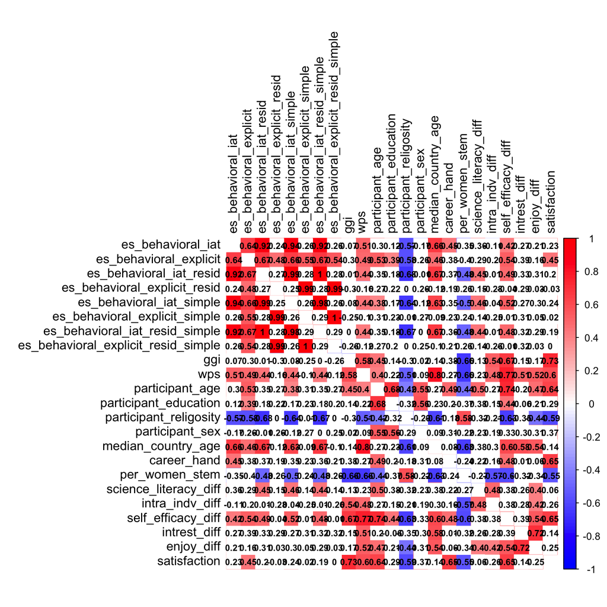

```r
language_df_with_ggi <- read_csv(LANGUAGE_DF_PATH)
language_df_corr <- language_df_with_ggi %>%
  select(-country_name) %>%
  select_if(is.numeric) %>%
  select(-contains("weighted"), -contains("stoet"))


corr_mat <- cor(language_df_corr,
                use = "pairwise.complete.obs")

p.mat <- corrplot::cor.mtest(language_df_corr,
                  conf.level = (1-ALPHA),
                  use = "pairwise.complete.obs")$p

corrplot::corrplot(corr_mat, method = "color",  col = cols,
         order = "original", number.cex = .7,
         addCoef.col = "black",
         p.mat = p.mat, sig.level = ALPHA, insig = "blank",
         tl.col = "black", tl.srt = 90,
         diag = FALSE)
```

### Regressions predicting behavioral data

##### Career language

# predicting implicit

```r
df <- language_df_with_ggi %>%
  select(language_name, wiki_language_code, es_behavioral_iat_resid_simple,
         career_hand, wps, median_country_age) %>%
  filter(!is.na(career_hand))

lm(es_behavioral_iat_resid_simple  ~  career_hand,
data = df) %>%
  summary()
```

```
##
## Call:
## lm(formula = es_behavioral_iat_resid_simple ~ career_hand, data = df)
##
## Residuals:
##       Min        1Q    Median        3Q       Max
## -0.043231 -0.016221  0.002529  0.012878  0.032721
##
## Coefficients:
##             Estimate Std. Error t value Pr(>|t|)
## (Intercept) -0.01570    0.00932  -1.685    0.109
## career_hand  0.03019    0.01819   1.660    0.114
##
## Residual standard error: 0.0219 on 18 degrees of freedom
## Multiple R-squared:  0.1328, Adjusted R-squared:  0.08462
## F-statistic: 2.756 on 1 and 18 DF,  p-value: 0.1142
```

```r
lm(es_behavioral_iat_resid_simple  ~  career_hand  + median_country_age,
data = df) %>%
  summary()
```

```
##
## Call:
## lm(formula = es_behavioral_iat_resid_simple ~ career_hand + median_country_age,
##     data = df)
##
## Residuals:
##       Min        1Q    Median        3Q       Max
## -0.034234 -0.008576 -0.000531  0.009767  0.039981
##
## Coefficients:
##                      Estimate Std. Error t value Pr(>|t|)
## (Intercept)        -0.0805857  0.0239259  -3.368  0.00365 **
## career_hand         0.0264789  0.0154100   1.718  0.10390
## median_country_age  0.0017581  0.0006122   2.872  0.01058 *
## ---
## Signif. codes:  0 '***' 0.001 '**' 0.01 '*' 0.05 '.' 0.1 ' ' 1
##
## Residual standard error: 0.01849 on 17 degrees of freedom
## Multiple R-squared:  0.416,  Adjusted R-squared:  0.3473
## F-statistic: 6.056 on 2 and 17 DF,  p-value: 0.01033
```

```r
lm(es_behavioral_iat_resid_simple  ~  career_hand  + wps  + median_country_age,
data = df) %>%
  summary()
```

```
##
## Call:
## lm(formula = es_behavioral_iat_resid_simple ~ career_hand + wps +
##     median_country_age, data = df)
##
## Residuals:
##       Min        1Q    Median        3Q       Max
## -0.031290 -0.005586 -0.001167  0.003722  0.044498
##
## Coefficients:
##                     Estimate Std. Error t value Pr(>|t|)
## (Intercept)        -0.049512   0.028651  -1.728  0.10322
## career_hand         0.038297   0.016012   2.392  0.02940 *
## wps                -0.150602   0.085527  -1.761  0.09736 .
## median_country_age  0.003818   0.001305   2.926  0.00989 **
## ---
## Signif. codes:  0 '***' 0.001 '**' 0.01 '*' 0.05 '.' 0.1 ' ' 1
##
## Residual standard error: 0.01744 on 16 degrees of freedom
## Multiple R-squared:  0.5108, Adjusted R-squared:  0.4191
## F-statistic:  5.57 on 3 and 16 DF,  p-value: 0.00822
```

```r
lm(es_behavioral_iat_resid_simple  ~  career_hand  + wps  + median_country_age + es_behavioral_explicit_resid_simple,
data = language_df_with_ggi) %>%
  summary()
```

```
##
## Call:
## lm(formula = es_behavioral_iat_resid_simple ~ career_hand + wps +
##     median_country_age + es_behavioral_explicit_resid_simple,
##     data = language_df_with_ggi)
##
## Residuals:
##       Min        1Q    Median        3Q       Max
## -0.028181 -0.007655 -0.000877  0.004544  0.041064
##
## Coefficients:
##                                      Estimate Std. Error t value Pr(>|t|)
## (Intercept)                         -0.053589   0.028181  -1.902   0.0766
## career_hand                          0.033171   0.016130   2.056   0.0576
## wps                                 -0.138942   0.084083  -1.652   0.1192
## median_country_age                   0.003729   0.001277   2.919   0.0106
## es_behavioral_explicit_resid_simple  0.031077   0.023564   1.319   0.2070
##
## (Intercept)                         .
## career_hand                         .
## wps
## median_country_age                  *
## es_behavioral_explicit_resid_simple
## ---
## Signif. codes:  0 '***' 0.001 '**' 0.01 '*' 0.05 '.' 0.1 ' ' 1
##
## Residual standard error: 0.01706 on 15 degrees of freedom
##   (14 observations deleted due to missingness)
## Multiple R-squared:  0.5617, Adjusted R-squared:  0.4448
## F-statistic: 4.805 on 4 and 15 DF,  p-value: 0.01073
```

```r
lm(es_behavioral_iat_resid_simple  ~  career_hand  + ggi,
data = language_df_with_ggi) %>%
  summary()
```

```
##
## Call:
## lm(formula = es_behavioral_iat_resid_simple ~ career_hand + ggi,
##     data = language_df_with_ggi)
##
## Residuals:
##       Min        1Q    Median        3Q       Max
## -0.043220 -0.010557  0.001138  0.013283  0.032871
##
## Coefficients:
##             Estimate Std. Error t value Pr(>|t|)
## (Intercept) -0.05383    0.07043  -0.764    0.456
## career_hand  0.02550    0.02028   1.257    0.227
## ggi          0.05710    0.10167   0.562    0.582
##
## Residual standard error: 0.0226 on 16 degrees of freedom
##   (15 observations deleted due to missingness)
## Multiple R-squared:  0.1506, Adjusted R-squared:  0.04439
## F-statistic: 1.418 on 2 and 16 DF,  p-value: 0.271
```

```r
lm(es_behavioral_iat_resid_simple  ~  career_hand  + median_country_age +  ggi  ,
data = language_df_with_ggi) %>%
  summary()
```

```
##
## Call:
## lm(formula = es_behavioral_iat_resid_simple ~ career_hand + median_country_age +
##     ggi, data = language_df_with_ggi)
##
## Residuals:
##       Min        1Q    Median        3Q       Max
## -0.031698 -0.009682 -0.000557  0.005937  0.048012
##
## Coefficients:
##                      Estimate Std. Error t value Pr(>|t|)
## (Intercept)        -0.0793362  0.0588163  -1.349   0.1974
## career_hand         0.0291122  0.0167944   1.733   0.1035
## median_country_age  0.0025585  0.0008793   2.910   0.0108 *
## ggi                -0.0477660  0.0913576  -0.523   0.6087
## ---
## Signif. codes:  0 '***' 0.001 '**' 0.01 '*' 0.05 '.' 0.1 ' ' 1
##
## Residual standard error: 0.01866 on 15 degrees of freedom
##   (15 observations deleted due to missingness)
## Multiple R-squared:  0.457,  Adjusted R-squared:  0.3484
## F-statistic: 4.209 on 3 and 15 DF,  p-value: 0.02395
```

```r
lm(es_behavioral_iat_resid_simple ~  career_hand  + median_country_age +  ggi + es_behavioral_explicit_resid,
data = language_df_with_ggi) %>%
  summary()
```

```
##
## Call:
## lm(formula = es_behavioral_iat_resid_simple ~ career_hand + median_country_age +
##     ggi + es_behavioral_explicit_resid, data = language_df_with_ggi)
##
## Residuals:
##       Min        1Q    Median        3Q       Max
## -0.027529 -0.009008 -0.001623  0.008609  0.041758
##
## Coefficients:
##                                Estimate Std. Error t value Pr(>|t|)
## (Intercept)                  -0.1121632  0.0601025  -1.866   0.0831 .
## career_hand                   0.0202013  0.0170588   1.184   0.2560
## median_country_age            0.0024612  0.0008432   2.919   0.0112 *
## ggi                           0.0075075  0.0943652   0.080   0.9377
## es_behavioral_explicit_resid  0.0683313  0.0440898   1.550   0.1435
## ---
## Signif. codes:  0 '***' 0.001 '**' 0.01 '*' 0.05 '.' 0.1 ' ' 1
##
## Residual standard error: 0.01785 on 14 degrees of freedom
##   (15 observations deleted due to missingness)
## Multiple R-squared:  0.5365, Adjusted R-squared:  0.4041
## F-statistic: 4.052 on 4 and 14 DF,  p-value: 0.02184
```

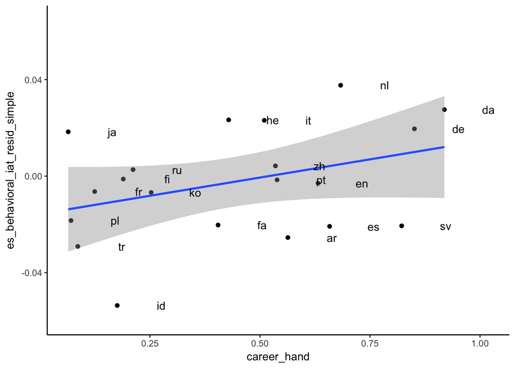

```r
ggplot(language_df_with_ggi, aes(x = career_hand, y = es_behavioral_iat_resid_simple)) +
  geom_point() +
  geom_smooth(method = "lm") +
  geom_text(aes(label = wiki_language_code, x = career_hand + .1 )) +
  theme_classic()
```

# predicting explicit

```r
lm(es_behavioral_explicit_resid_simple ~  career_hand  + median_country_age +  wps + es_behavioral_iat_resid_simple,
data = language_df_with_ggi) %>%
  summary()
```

```
##
## Call:
## lm(formula = es_behavioral_explicit_resid_simple ~ career_hand +
##     median_country_age + wps + es_behavioral_iat_resid_simple,
##     data = language_df_with_ggi)
##
## Residuals:
##      Min       1Q   Median       3Q      Max
## -0.21572 -0.12066 -0.04548  0.11726  0.34198
##
## Coefficients:
##                                 Estimate Std. Error t value Pr(>|t|)
## (Intercept)                     0.296710   0.316497   0.937    0.363
## career_hand                     0.036890   0.189187   0.195    0.848
## median_country_age             -0.009889   0.016395  -0.603    0.555
## wps                             0.128336   0.947617   0.135    0.894
## es_behavioral_iat_resid_simple  3.343393   2.535162   1.319    0.207
##
## Residual standard error: 0.1769 on 15 degrees of freedom
##   (14 observations deleted due to missingness)
## Multiple R-squared:  0.1604, Adjusted R-squared:  -0.06344
## F-statistic: 0.7166 on 4 and 15 DF,  p-value: 0.5936
```

```r
lm(es_behavioral_explicit_resid_simple ~  es_behavioral_iat_resid_simple  ,
data = language_df_with_ggi) %>%
  summary()
```

```
##
## Call:
## lm(formula = es_behavioral_explicit_resid_simple ~ es_behavioral_iat_resid_simple,
##     data = language_df_with_ggi)
##
## Residuals:
##      Min       1Q   Median       3Q      Max
## -0.36144 -0.12194  0.01977  0.10849  0.40263
##
## Coefficients:
##                                Estimate Std. Error t value Pr(>|t|)
## (Intercept)                     0.01282    0.03184   0.403    0.690
## es_behavioral_iat_resid_simple  1.76773    1.09420   1.616    0.117
##
## Residual standard error: 0.1705 on 29 degrees of freedom
##   (3 observations deleted due to missingness)
## Multiple R-squared:  0.08257,    Adjusted R-squared:  0.05093
## F-statistic:  2.61 on 1 and 29 DF,  p-value: 0.117
```

# flowers isn’t predictive

```r
flowers <- read_csv("../6_flowers/data/flowers_effect_sizes_google.csv",
                    col_names = c("wiki_language_code", "x", "y", "flower_google")) %>%
                      select(-x, -y)

language_df_with_ggi_lang <- left_join(language_df_with_ggi, flowers)

lm(es_behavioral_iat_resid_simple ~  flower_google  + median_country_age +  wps + es_behavioral_explicit_resid_simple,
data = language_df_with_ggi_lang) %>%
  summary()
```

```
##
## Call:
## lm(formula = es_behavioral_iat_resid_simple ~ flower_google +
##     median_country_age + wps + es_behavioral_explicit_resid_simple,
##     data = language_df_with_ggi_lang)
##
## Residuals:
##       Min        1Q    Median        3Q       Max
## -0.033220 -0.011269 -0.002108  0.007532  0.043080
##
## Coefficients:
##                                       Estimate Std. Error t value Pr(>|t|)
## (Intercept)                         -0.0870732  0.0283686  -3.069  0.00511
## flower_google                       -0.0077162  0.0175339  -0.440  0.66367
## median_country_age                   0.0038050  0.0009725   3.913  0.00062
## wps                                 -0.0695074  0.0640161  -1.086  0.28794
## es_behavioral_explicit_resid_simple  0.0513877  0.0227802   2.256  0.03308
##
## (Intercept)                         **
## flower_google
## median_country_age                  ***
## wps
## es_behavioral_explicit_resid_simple *
## ---
## Signif. codes:  0 '***' 0.001 '**' 0.01 '*' 0.05 '.' 0.1 ' ' 1
##
## Residual standard error: 0.01985 on 25 degrees of freedom
##   (4 observations deleted due to missingness)
## Multiple R-squared:  0.5898, Adjusted R-squared:  0.5242
## F-statistic: 8.988 on 4 and 25 DF,  p-value: 0.0001216
```

```r
lm(career_hand ~  flower_google,
data = language_df_with_ggi_lang) %>%
  summary()
```

```
##
## Call:
## lm(formula = career_hand ~ flower_google, data = language_df_with_ggi_lang)
##
## Residuals:
##      Min       1Q   Median       3Q      Max
## -0.37479 -0.26314  0.06517  0.18589  0.47810
##
## Coefficients:
##               Estimate Std. Error t value Pr(>|t|)
## (Intercept)     0.2790     0.2787   1.001     0.33
## flower_google   0.1319     0.2280   0.578     0.57
##
## Residual standard error: 0.2812 on 18 degrees of freedom
##   (14 observations deleted due to missingness)
## Multiple R-squared:  0.01824,    Adjusted R-squared:  -0.0363
## F-statistic: 0.3344 on 1 and 18 DF,  p-value: 0.5702
```

```r
lm(es_behavioral_explicit_resid_simple ~  flower_google   + median_country_age +  wps+ es_behavioral_iat_resid_simple,
data = language_df_with_ggi_lang) %>%
  summary()
```

```
##
## Call:
## lm(formula = es_behavioral_explicit_resid_simple ~ flower_google +
##     median_country_age + wps + es_behavioral_iat_resid_simple,
##     data = language_df_with_ggi_lang)
##
## Residuals:
##      Min       1Q   Median       3Q      Max
## -0.33479 -0.11997 -0.01007  0.07406  0.29762
##
## Coefficients:
##                                 Estimate Std. Error t value Pr(>|t|)
## (Intercept)                     0.478314   0.248622   1.924   0.0658 .
## flower_google                  -0.196089   0.135293  -1.449   0.1597
## median_country_age             -0.006350   0.009800  -0.648   0.5229
## wps                             0.003985   0.524247   0.008   0.9940
## es_behavioral_iat_resid_simple  3.291110   1.458949   2.256   0.0331 *
## ---
## Signif. codes:  0 '***' 0.001 '**' 0.01 '*' 0.05 '.' 0.1 ' ' 1
##
## Residual standard error: 0.1589 on 25 degrees of freedom
##   (4 observations deleted due to missingness)
## Multiple R-squared:  0.2836, Adjusted R-squared:  0.169
## F-statistic: 2.474 on 4 and 25 DF,  p-value: 0.0703
```

Career google is correlated with career hand, but doesn’t predict anything

```r
career_google <- read_csv("../2_pretrained_w2v_models/embedding_IAT/google_translate/career_effect_sizes_google.csv",  col_names = c("wiki_language_code", "x", "y", "career_google")) %>%
       select(-x, -y)

language_df_with_ggi_lang_cg<- left_join(language_df_with_ggi_lang, career_google)

cor.test(language_df_with_ggi_lang_cg$career_google, language_df_with_ggi_lang_cg$career_hand)
```

```
##
##  Pearson's product-moment correlation
##
## data:  language_df_with_ggi_lang_cg$career_google and language_df_with_ggi_lang_cg$career_hand
## t = 3.2427, df = 17, p-value = 0.004787
## alternative hypothesis: true correlation is not equal to 0
## 95 percent confidence interval:
##  0.2279906 0.8372936
## sample estimates:
##       cor
## 0.6181836
```

```r
lm(es_behavioral_iat_resid_simple ~  career_google  + median_country_age +  wps ,
data = language_df_with_ggi_lang_cg) %>%
  summary()
```

```
##
## Call:
## lm(formula = es_behavioral_iat_resid_simple ~ career_google +
##     median_country_age + wps, data = language_df_with_ggi_lang_cg)
##
## Residuals:
##       Min        1Q    Median        3Q       Max
## -0.030317 -0.010843 -0.000935  0.007284  0.051043
##
## Coefficients:
##                      Estimate Std. Error t value Pr(>|t|)
## (Intercept)        -0.0587472  0.0296510  -1.981  0.05964 .
## career_google       0.0074177  0.0099501   0.745  0.46353
## median_country_age  0.0029378  0.0008443   3.480  0.00203 **
## wps                -0.0800187  0.0636686  -1.257  0.22144
## ---
## Signif. codes:  0 '***' 0.001 '**' 0.01 '*' 0.05 '.' 0.1 ' ' 1
##
## Residual standard error: 0.01875 on 23 degrees of freedom
##   (7 observations deleted due to missingness)
## Multiple R-squared:  0.4629, Adjusted R-squared:  0.3928
## F-statistic: 6.607 on 3 and 23 DF,  p-value: 0.002208
```

```r
lm(es_behavioral_iat_resid_simple ~  career_google  + median_country_age +  ggi + es_behavioral_explicit_resid,
data = language_df_with_ggi_lang_cg) %>%
  summary()
```

```
##
## Call:
## lm(formula = es_behavioral_iat_resid_simple ~ career_google +
##     median_country_age + ggi + es_behavioral_explicit_resid,
##     data = language_df_with_ggi_lang_cg)
##
## Residuals:
##       Min        1Q    Median        3Q       Max
## -0.028818 -0.008436 -0.001865  0.003451  0.045834
##
## Coefficients:
##                                Estimate Std. Error t value Pr(>|t|)
## (Intercept)                  -0.1237638  0.0455154  -2.719   0.0129 *
## career_google                 0.0026416  0.0083390   0.317   0.7545
## median_country_age            0.0027843  0.0005433   5.125 4.47e-05 ***
## ggi                           0.0164415  0.0591157   0.278   0.7836
## es_behavioral_explicit_resid  0.0794470  0.0293496   2.707   0.0132 *
## ---
## Signif. codes:  0 '***' 0.001 '**' 0.01 '*' 0.05 '.' 0.1 ' ' 1
##
## Residual standard error: 0.01641 on 21 degrees of freedom
##   (8 observations deleted due to missingness)
## Multiple R-squared:  0.6202, Adjusted R-squared:  0.5479
## F-statistic: 8.574 on 4 and 21 DF,  p-value: 0.0002889
```

```r
lm(es_behavioral_explicit_resid_simple ~  career_google  + median_country_age +  wps + es_behavioral_iat_resid_simple,
data = language_df_with_ggi_lang_cg) %>%
  summary()
```

```
##
## Call:
## lm(formula = es_behavioral_explicit_resid_simple ~ career_google +
##     median_country_age + wps + es_behavioral_iat_resid_simple,
##     data = language_df_with_ggi_lang_cg)
##
## Residuals:
##      Min       1Q   Median       3Q      Max
## -0.30699 -0.11402 -0.03717  0.10974  0.36287
##
## Coefficients:
##                                Estimate Std. Error t value Pr(>|t|)
## (Intercept)                     0.43186    0.29680   1.455   0.1598
## career_google                  -0.02124    0.09316  -0.228   0.8218
## median_country_age             -0.01719    0.00965  -1.781   0.0887 .
## wps                             0.31927    0.60890   0.524   0.6053
## es_behavioral_iat_resid_simple  5.01497    1.92902   2.600   0.0164 *
## ---
## Signif. codes:  0 '***' 0.001 '**' 0.01 '*' 0.05 '.' 0.1 ' ' 1
##
## Residual standard error: 0.1735 on 22 degrees of freedom
##   (7 observations deleted due to missingness)
## Multiple R-squared:  0.2474, Adjusted R-squared:  0.1106
## F-statistic: 1.808 on 4 and 22 DF,  p-value: 0.1633
```